# Phase_2

Samir Mohamed

2025-2-20

- As our sample size is more than 30, we will use the Z table all over our calculations
- ———–Introducing important libraries——–

```r
library(readxl)
```

```r
file_path <- "D:/Study_Habits/Study_Habits.xlsx"
Study_Habits <- read_excel(file_path)
library(ggplot2)
library(dplyr)
library(psych)
library(janitor)
library(knitr)
```

- ————-outliers removing built in function————–

```r
outliers <- function(column) {
  Q1 <- quantile(column, 0.25, na.rm = TRUE)
  Q3 <- quantile(column, 0.75, na.rm = TRUE)
  IQR <- Q3 - Q1
  lower_bound <- Q1 - 1.5 * IQR
  upper_bound <- Q3 + 1.5 * IQR
  column <- ifelse(column < lower_bound | column > upper_bound,
                   median(column, na.rm = TRUE),
                   column)
  return(column)}
```

- ————-Data filtration————–

```r
GPA <-
  as.numeric(Study_Habits$GPA)
GPA <-
  outliers(GPA)
Homework_time <-
  as.numeric(Study_Habits$`Homework's time`)
Studying_hours <-
  as.numeric(Study_Habits$`Studying hours`)
Studying_hours <-
  outliers(Studying_hours)
Age <-
  as.numeric(Study_Habits$Age)
Age <-
  outliers(Age)
Method <- sapply(strsplit(Study_Habits$`Studying Methods`, ";"), length)
original_levels <- c("Watching educational videos", "Rewriting notes", "Group study", "Flashcards", "Reading textbooks")
Method <- as.factor(Method)
levels(Method) <- original_levels
```

- ————-Statistical Analysis————–

# Confidence interval calculation

- We will use: CI = sample mean ± margin of error
- We will calculate the confidence interval with a 95% confidence level

```r
n = length(Age)
# 1- 95% Confidence Interval for GPA
confidence_level <- 0.95
z_value <- qnorm(1 - (1 - confidence_level) / 2)  # z=1.96 for 95% CI

# Calculate margin of error
margin_of_error <- z_value * (sd(Age) / sqrt(n))
margin_of_error
```

```
## [1] 0.1527245
```

```r
# Calculate confidence interval
CI_lower <- mean(Age) - margin_of_error
CI_upper <- mean(Age) + margin_of_error

CI_lower
```

```
## [1] 18.19792
```

```r
CI_upper
```

```
## [1] 18.50337
```

```r
n = length(Homework_time)
# 1- 95% Confidence Interval for GPA
confidence_level <- 0.95
z_value <- qnorm(1 - (1 - confidence_level) / 2)  # z=1.96 for 95% CI

# Calculate margin of error
margin_of_error <- z_value * (sd(Homework_time) / sqrt(n))
margin_of_error
```

```
## [1] 2.464643
```

```r
# Calculate confidence interval
CI_lower <- mean(Homework_time) - margin_of_error
CI_upper <- mean(Homework_time) + margin_of_error

CI_lower
```

```
## [1] 8.249643
```

```r
CI_upper
```

```
## [1] 13.17893
```

- This means we are 95% confident that the true population mean Homework’s time according to our sample lies between **8.249643** and **13.17893**.
- The margin of error is 2.46, which is a big number because the variation on the responses we collected

```r
n = length(Studying_hours)
# 1- 95% Confidence Interval for GPA
confidence_level <- 0.95
z_value <- qnorm(1 - (1 - confidence_level) / 2)  # z=1.96 for 95% CI

# Calculate margin of error
margin_of_error <- z_value * (sd(Studying_hours) / sqrt(n))
margin_of_error
```

```
## [1] 2.933122
```

```r
# Calculate confidence interval
CI_lower <- mean(Studying_hours) - margin_of_error
CI_upper <- mean(Studying_hours) + margin_of_error

CI_lower
```

```
## [1] 18.94999
```

```r
CI_upper
```

```
## [1] 24.81624
```

- This means we are 95% confident that the true population mean Studying hours according to our sample lies between **18.94999** and **24.81624**.
- The margin of error is 2.9, which is a big number because the variation on the responses we collected

# Hypothesis Testing

- **#GPA vs Gender**
- –Visualization–

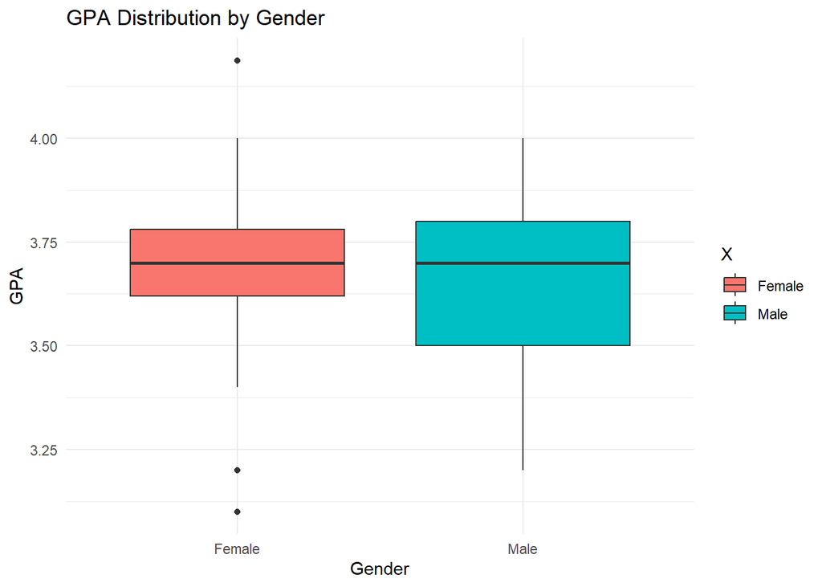

```r
library(ggplot2)
custom_data <- data.frame(
  X = Study_Habits$Gender,
  Y = GPA
)
male_data <- custom_data[custom_data$Gender == "Male", ]
female_data <- custom_data[custom_data$Gender == "Female", ]

# Create side-by-side bar plots
ggplot(custom_data, aes(x = X, y = Y, fill = X)) +
  geom_boxplot() +
  labs(title = "GPA Distribution by Gender",
       x = "Gender",
       y = "GPA") +
  theme_minimal()
```

- –Hypothesis testing using Regression Analysis–

```r
model <- lm(Y ~ X, data = custom_data)
summary(model)
```

```
##
## Call:
## lm(formula = Y ~ X, data = custom_data)
##
## Residuals:
##      Min       1Q   Median       3Q      Max
## -0.57671 -0.15930  0.02329  0.12070  0.51129
##
## Coefficients:
##             Estimate Std. Error t value Pr(>|t|)
## (Intercept) 3.676706   0.036186 101.607   <2e-16 ***
## XMale       0.002596   0.048423   0.054    0.957
## ---
## Signif. codes:  0 '***' 0.001 '**' 0.01 '*' 0.05 '.' 0.1 ' ' 1
##
## Residual standard error: 0.211 on 75 degrees of freedom
## Multiple R-squared:  3.833e-05,  Adjusted R-squared:  -0.01329
## F-statistic: 0.002875 on 1 and 75 DF,  p-value: 0.9574
```

- high p-value (greater than 0.05) indicates that the effect of Gender on GPA is not statistically significant. Thus, there’s no evidence that gender has a meaningful impact on GPA in our dataset.
- **#GPA vs Fathers’ Education Level**
- –Visualization–

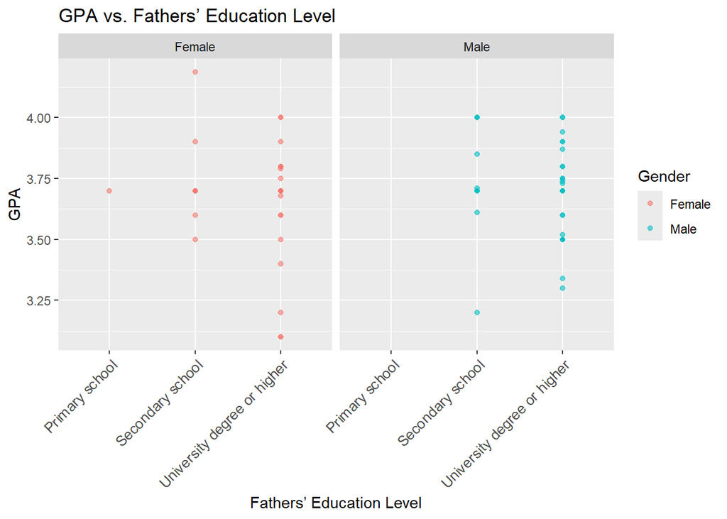

```r
library(ggplot2)
custom_data <- data.frame(
  Father = Study_Habits$`Parents Education Level`,
  GPA = GPA,
  Y = Study_Habits$Gender
)
ggplot(custom_data, aes(x = Father, y = GPA, color = Y)) +
  geom_point(alpha = 0.6) +
  geom_smooth(method = "lm", col = "blue", se = FALSE) +
  facet_wrap(~ Study_Habits$Gender) +
  labs(title = "GPA vs. Fathers’ Education Level",
       x = "Fathers’ Education Level",
       y = "GPA",
       color = "Gender") +
  theme(axis.text.x = element_text(size = 10, angle = 45, hjust = 1))  # Adjust x-axis text properties
```

- –Hypothesis testing using Regression Analysis–

```r
model <- lm(GPA ~ Father, data = custom_data)
summary(model)
```

```
##
## Call:
## lm(formula = GPA ~ Father, data = custom_data)
##
## Residuals:
##      Min       1Q   Median       3Q      Max
## -0.55621 -0.14767  0.04379  0.13379  0.44033
##
## Coefficients:
##                                   Estimate Std. Error t value Pr(>|t|)
## (Intercept)                        3.70000    0.20872  17.727   <2e-16 ***
## FatherSecondary school             0.04767    0.21444   0.222    0.825
## FatherUniversity degree or higher -0.04379    0.21051  -0.208    0.836
## ---
## Signif. codes:  0 '***' 0.001 '**' 0.01 '*' 0.05 '.' 0.1 ' ' 1
##
## Residual standard error: 0.2087 on 74 degrees of freedom
## Multiple R-squared:  0.03456,    Adjusted R-squared:  0.008464
## F-statistic: 1.324 on 2 and 74 DF,  p-value: 0.2722
```

- high p-value (greater than 0.05) indicates that the effect of Fathers’ Education Level on GPA is not statistically significant. Thus, there’s no evidence that Fathers’ Education Level has a meaningful impact on GPA in our dataset.
- **#GPA vs Mothers’ Education Level**
- –Visualization–

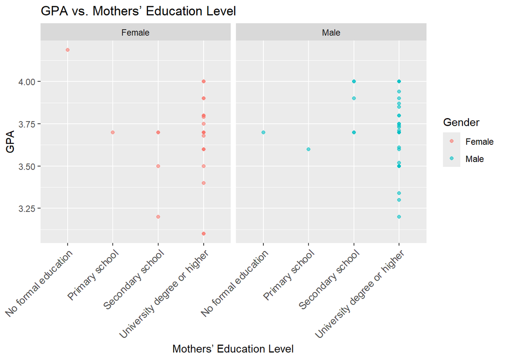

```r
library(ggplot2)
custom_data <- data.frame(
  Mother = Study_Habits$`Parents Education Level2`,
  GPA = GPA,
  Y = Study_Habits$Gender
)
ggplot(custom_data, aes(x = Mother, y = GPA, color = Y)) +
  geom_point(alpha = 0.6) +
  geom_smooth(method = "lm", col = "blue", se = FALSE) +
  facet_wrap(~ Study_Habits$Gender) +
  labs(title = "GPA vs. Mothers’ Education Level ",
       x = "Mothers’ Education Level",
       y = "GPA",
       color = "Gender")+
  theme(axis.text.x = element_text(size = 10, angle = 45, hjust = 1))  # Adjust x-axis text properties
```

- –Hypothesis testing using Regression Analysis–

```r
model <- lm(GPA ~ Mother, data = custom_data)
summary(model)
```

```
##
## Call:
## lm(formula = GPA ~ Mother, data = custom_data)
##
## Residuals:
##      Min       1Q   Median       3Q      Max
## -0.56609 -0.16609  0.03391  0.13391  0.33391
##
## Coefficients:
##                                   Estimate Std. Error t value Pr(>|t|)
## (Intercept)                         3.9440     0.1475  26.736   <2e-16 ***
## MotherPrimary school               -0.2940     0.2086  -1.409   0.1630
## MotherSecondary school             -0.2329     0.1631  -1.428   0.1575
## MotherUniversity degree or higher  -0.2779     0.1498  -1.855   0.0676 .
## ---
## Signif. codes:  0 '***' 0.001 '**' 0.01 '*' 0.05 '.' 0.1 ' ' 1
##
## Residual standard error: 0.2086 on 73 degrees of freedom
## Multiple R-squared:  0.04852,    Adjusted R-squared:  0.00942
## F-statistic: 1.241 on 3 and 73 DF,  p-value: 0.3011
```

- high p-value (greater than 0.05) indicates that the effect of Mothers’ Education Level on GPA is not statistically significant. Thus, there’s no evidence that Mothers’ Education Level has a meaningful impact on GPA in our dataset.
- **#GPA vs Family Structure**
- –Visualization–

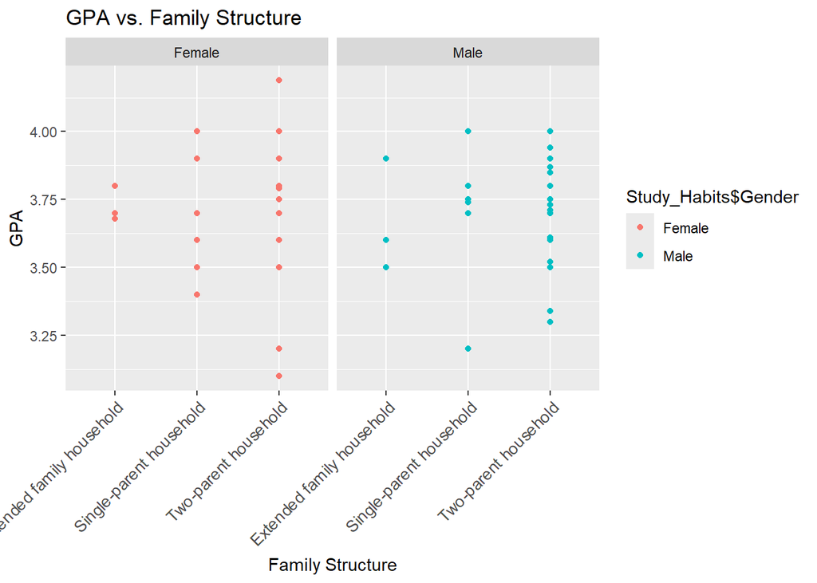

```r
library(ggplot2)
custom_data <- data.frame(
  Fam = Study_Habits$`Family Structure`,
  GPA = GPA
)
ggplot(custom_data, aes(x = Fam, y = GPA, color = Study_Habits$Gender)) +
  geom_point() +
  geom_smooth(method = "lm", col = "blue") +
  facet_wrap(~ Study_Habits$Gender) +
  labs(title = "GPA vs. Family Structure ",
       x = "Family Structure",
       y = "GPA")+
  theme(axis.text.x = element_text(size = 10, angle = 45, hjust = 1))  # Adjust x-axis text properties
```

- –Hypothesis testing using Regression Analysis–

```r
model <- lm(GPA ~ Fam, data = custom_data)
summary(model)
```

```
##
## Call:
## lm(formula = GPA ~ Fam, data = custom_data)
##
## Residuals:
##      Min       1Q   Median       3Q      Max
## -0.57349 -0.15349  0.02651  0.11651  0.51451
##
## Coefficients:
##                             Estimate Std. Error t value Pr(>|t|)
## (Intercept)                 3.668571   0.080208  45.738   <2e-16 ***
## Fam Single-parent household 0.025639   0.093827   0.273    0.785
## FamTwo-parent household     0.004919   0.085535   0.058    0.954
## ---
## Signif. codes:  0 '***' 0.001 '**' 0.01 '*' 0.05 '.' 0.1 ' ' 1
##
## Residual standard error: 0.2122 on 74 degrees of freedom
## Multiple R-squared:  0.001992,   Adjusted R-squared:  -0.02498
## F-statistic: 0.07384 on 2 and 74 DF,  p-value: 0.9289
```

- high p-value (greater than 0.05) indicates that the effect of Family Structure on GPA is not statistically significant. Thus, there’s no evidence that Family Structure has a meaningful impact on GPA in our dataset.
- **#GPA vs Lifestyle Factors**
- –Visualization–

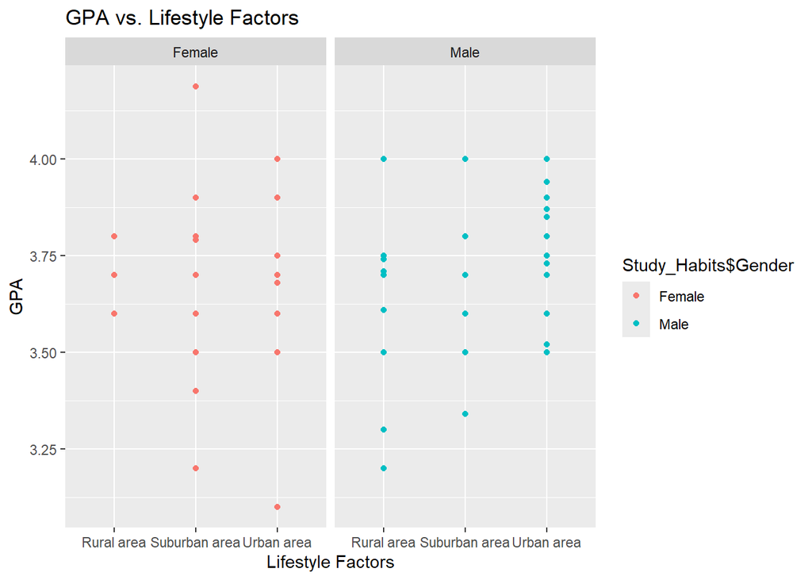

```r
library(ggplot2)
custom_data <- data.frame(
  Life = Study_Habits$`  Lifestyle Factors (Urban vs. Rural Living)`,
  GPA = GPA
)
ggplot(custom_data, aes(x = Life, y = GPA, color = Study_Habits$Gender)) +
  geom_point() +
  geom_smooth(method = "lm", col = "blue") +
  facet_wrap(~ Study_Habits$Gender) +
  labs(title = "GPA vs. Lifestyle Factors ",
       x = "Lifestyle Factors",
       y = "GPA")
```

- –Hypothesis testing using Regression Analysis–

```r
model <- lm(GPA ~ Life, data = custom_data)
summary(model)
```

```
##
## Call:
## lm(formula = GPA ~ Life, data = custom_data)
##
## Residuals:
##      Min       1Q   Median       3Q      Max
## -0.59205 -0.13813  0.01736  0.11187  0.50536
##
## Coefficients:
##                   Estimate Std. Error t value Pr(>|t|)
## (Intercept)        3.63812    0.05284  68.855   <2e-16 ***
## LifeSuburban area  0.04451    0.06944   0.641    0.524
## LifeUrban area     0.05393    0.06275   0.859    0.393
## ---
## Signif. codes:  0 '***' 0.001 '**' 0.01 '*' 0.05 '.' 0.1 ' ' 1
##
## Residual standard error: 0.2113 on 74 degrees of freedom
## Multiple R-squared:  0.01007,    Adjusted R-squared:  -0.01669
## F-statistic: 0.3762 on 2 and 74 DF,  p-value: 0.6878
```

- high p-value (greater than 0.05) indicates that the effect of Lifestyle Factors on GPA is not statistically significant. Thus, there’s no evidence that Lifestyle Factors has a meaningful impact on GPA in our dataset.
- **#GPA vs Digital Access**
- –Visualization–

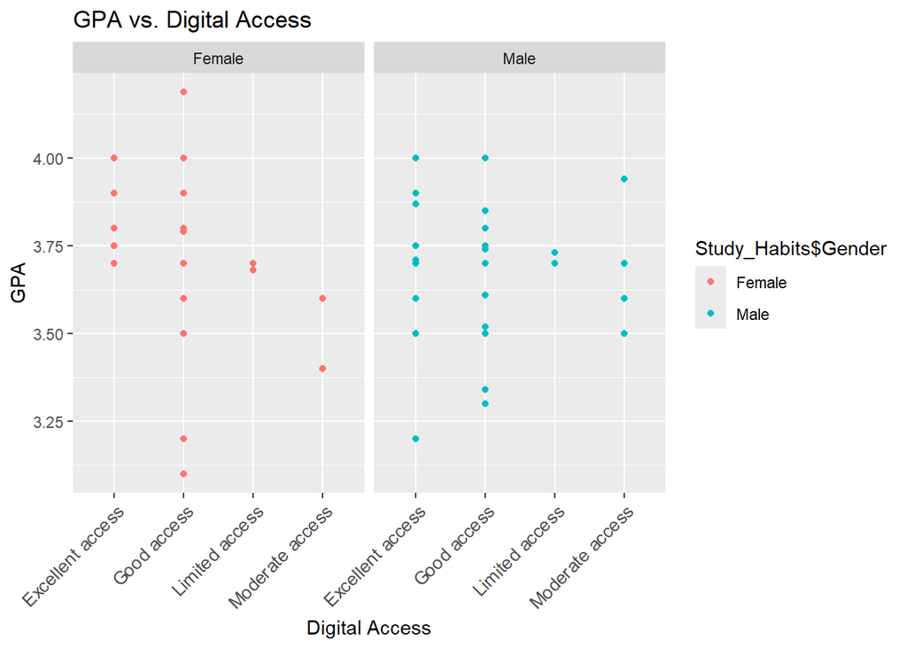

```r
library(ggplot2)
custom_data <- data.frame(
  Dig = Study_Habits$`Digital Access`,
  GPA = GPA
)
ggplot(custom_data, aes(x = Dig, y = GPA, color = Study_Habits$Gender)) +
  geom_point() +
  geom_smooth(method = "lm", col = "blue") +
  facet_wrap(~ Study_Habits$Gender) +
  labs(title = "GPA vs. Digital Access ",
       x = "Digital Access",
       y = "GPA")+
  theme(axis.text.x = element_text(size = 10, angle = 45, hjust = 1))  # Adjust x-axis text properties
```

- –Hypothesis testing using Regression Analysis–

```r
model <- lm(GPA ~ Dig, data = custom_data)
summary(model)
```

```
##
## Call:
## lm(formula = GPA ~ Dig, data = custom_data)
##
## Residuals:
##      Min       1Q   Median       3Q      Max
## -0.54968 -0.10571  0.01857  0.13857  0.53832
##
## Coefficients:
##                    Estimate Std. Error t value Pr(>|t|)
## (Intercept)         3.73143    0.03950  94.458   <2e-16 ***
## DigGood access     -0.08174    0.05206  -1.570    0.121
## DigLimited access  -0.02893    0.11173  -0.259    0.796
## DigModerate access -0.12571    0.08833  -1.423    0.159
## ---
## Signif. codes:  0 '***' 0.001 '**' 0.01 '*' 0.05 '.' 0.1 ' ' 1
##
## Residual standard error: 0.209 on 73 degrees of freedom
## Multiple R-squared:  0.04473,    Adjusted R-squared:  0.005477
## F-statistic:  1.14 on 3 and 73 DF,  p-value: 0.3389
```

- high p-value (greater than 0.05) indicates that the effect of Digital Access on GPA is not statistically significant. Thus, there’s no evidence that Digital Access has a meaningful impact on GPA in our dataset.
- **#GPA vs Study Environment**
- –Visualization–

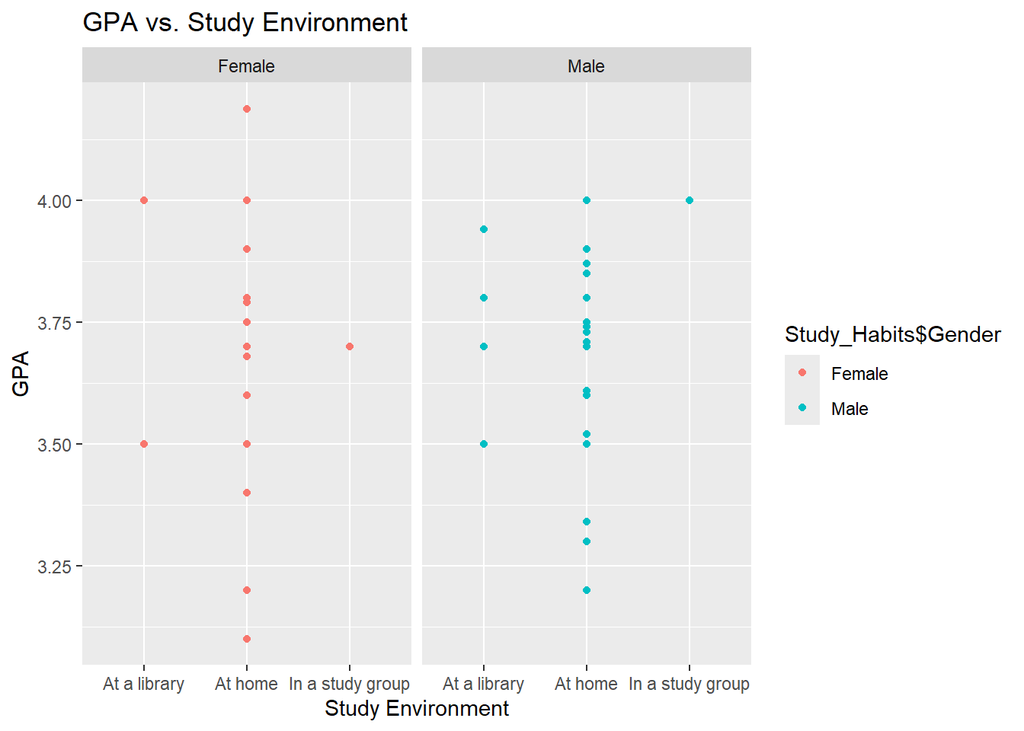

```r
library(ggplot2)
custom_data <- data.frame(
  Env = Study_Habits$`Study Environment`,
  GPA = GPA
)
ggplot(custom_data, aes(x = Env, y = GPA, color = Study_Habits$Gender)) +
  geom_point() +
  geom_smooth(method = "lm", col = "blue") +
  facet_wrap(~ Study_Habits$Gender) +
  labs(title = "GPA vs. Study Environment ",
       x = "Study Environment",
       y = "GPA")
```

- –Hypothesis testing using Regression Analysis–

```r
model <- lm(GPA ~ Env, data = custom_data)
summary(model)
```

```
##
## Call:
## lm(formula = GPA ~ Env, data = custom_data)
##
## Residuals:
##     Min      1Q  Median      3Q     Max
## -0.5678 -0.1500  0.0322  0.1222  0.5202
##
## Coefficients:
##                     Estimate Std. Error t value Pr(>|t|)
## (Intercept)          3.74000    0.08555  43.716   <2e-16 ***
## EnvAt home          -0.07220    0.08919  -0.810    0.421
## EnvIn a study group  0.11000    0.17110   0.643    0.522
## ---
## Signif. codes:  0 '***' 0.001 '**' 0.01 '*' 0.05 '.' 0.1 ' ' 1
##
## Residual standard error: 0.2096 on 74 degrees of freedom
## Multiple R-squared:  0.02678,    Adjusted R-squared:  0.0004742
## F-statistic: 1.018 on 2 and 74 DF,  p-value: 0.3663
```

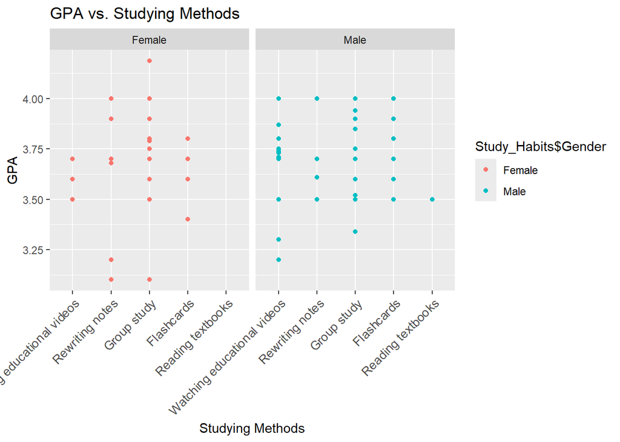

```r
library(ggplot2)
custom_data <- data.frame(
  Method = Method,
  GPA = GPA
)
ggplot(custom_data, aes(x = Method, y = GPA, color = Study_Habits$Gender)) +
  geom_point() +
  geom_smooth(method = "lm", col = "blue") +
  facet_wrap(~ Study_Habits$Gender) +
  labs(title = "GPA vs. Studying Methods ",
       x = "Studying Methods",
       y = "GPA")+
  theme(axis.text.x = element_text(size = 10, angle = 45, hjust = 1))
```

- –Hypothesis testing using Regression Analysis–

```r
model <- lm(GPA ~ Method, data = custom_data)
summary(model)
```

```
##
## Call:
## lm(formula = GPA ~ Method, data = custom_data)
##
## Residuals:
##      Min       1Q   Median       3Q      Max
## -0.59123 -0.10000  0.03158  0.10000  0.49677
##
## Coefficients:
##                          Estimate Std. Error t value Pr(>|t|)
## (Intercept)              3.668421   0.049038  74.807   <2e-16 ***
## MethodRewriting notes   -0.009088   0.073829  -0.123    0.902
## MethodGroup study        0.022805   0.062279   0.366    0.715
## MethodFlashcards         0.031579   0.080984   0.390    0.698
## MethodReading textbooks -0.168421   0.219306  -0.768    0.445
## ---
## Signif. codes:  0 '***' 0.001 '**' 0.01 '*' 0.05 '.' 0.1 ' ' 1
##
## Residual standard error: 0.2138 on 72 degrees of freedom
## Multiple R-squared:  0.01479,    Adjusted R-squared:  -0.03994
## F-statistic: 0.2703 on 4 and 72 DF,  p-value: 0.8962
```

- high p-value (greater than 0.05) indicates that the effect of Studying Methods on GPA is not statistically significant. Thus, there’s no evidence that Studying Methods has a meaningful impact on GPA in our dataset.
- **#GPA vs Taking Notes**
- –Visualization–

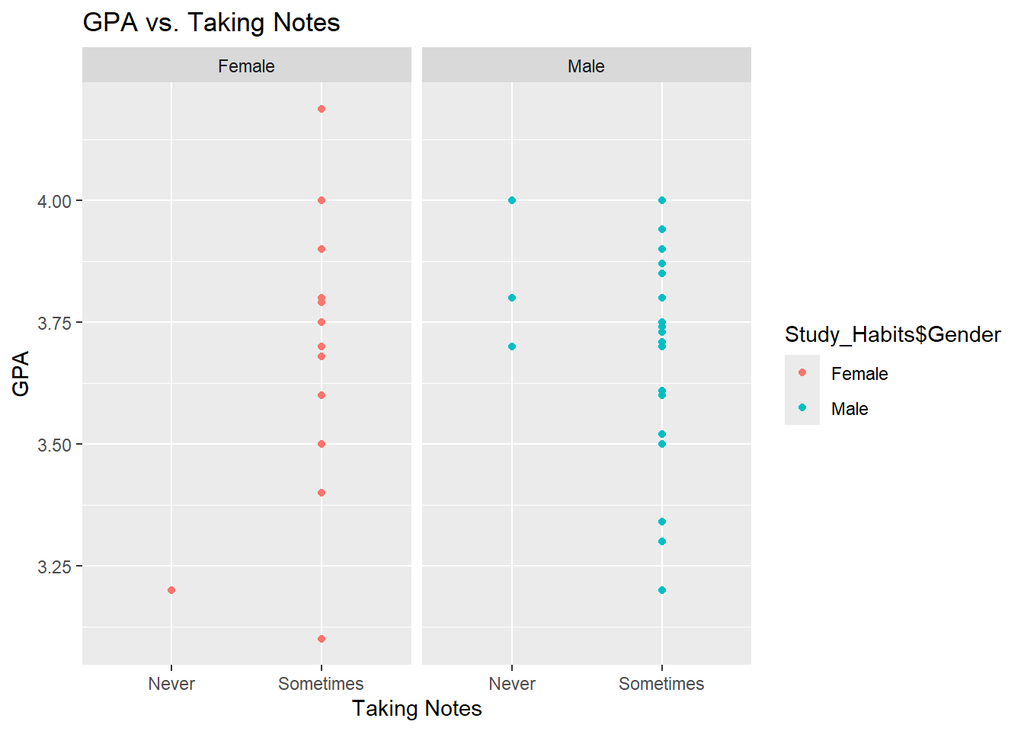

```r
library(ggplot2)
custom_data <- data.frame(
  Notes = Study_Habits$`Taking Notes`,
  GPA = GPA
)
ggplot(custom_data, aes(x = Notes, y = GPA, color = Study_Habits$Gender)) +
  geom_point() +
  geom_smooth(method = "lm", col = "blue") +
  facet_wrap(~ Study_Habits$Gender) +
  labs(title = "GPA vs. Taking Notes ",
       x = "Taking Notes",
       y = "GPA")
```

- –Hypothesis testing using Regression Analysis–

```r
model <- lm(GPA ~ Notes, data = custom_data)
summary(model)
```

```
##
## Call:
## lm(formula = GPA ~ Notes, data = custom_data)
##
## Residuals:
##      Min       1Q   Median       3Q      Max
## -0.57833 -0.15833  0.02167  0.12167  0.50967
##
## Coefficients:
##                Estimate Std. Error t value Pr(>|t|)
## (Intercept)    3.675000   0.105500  34.834   <2e-16 ***
## NotesSometimes 0.003329   0.108352   0.031    0.976
## ---
## Signif. codes:  0 '***' 0.001 '**' 0.01 '*' 0.05 '.' 0.1 ' ' 1
##
## Residual standard error: 0.211 on 75 degrees of freedom
## Multiple R-squared:  1.258e-05,  Adjusted R-squared:  -0.01332
## F-statistic: 0.0009438 on 1 and 75 DF,  p-value: 0.9756
```

- high p-value (greater than 0.05) indicates that the effect of Taking Notes on GPA is not statistically significant. Thus, there’s no evidence that Taking Notes has a meaningful impact on GPA in our dataset.
- **#GPA vs Reviewing Notes**
- –Visualization–

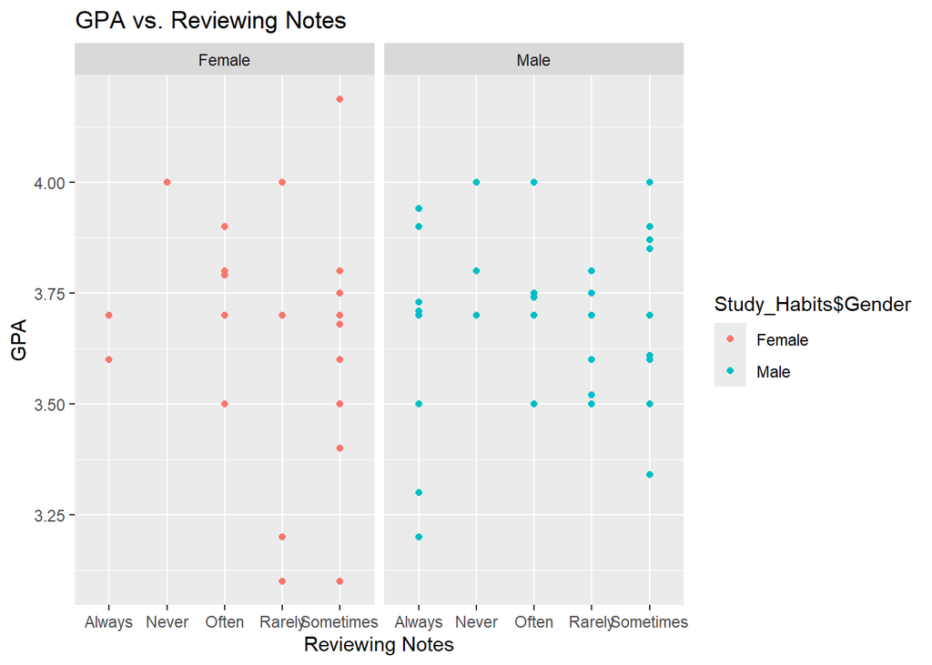

```r
library(ggplot2)
custom_data <- data.frame(
  Review = Study_Habits$`Reviewing Notes`,
  GPA = GPA
)
ggplot(custom_data, aes(x = Review, y = GPA, color = Study_Habits$Gender)) +
  geom_point() +
  geom_smooth(method = "lm", col = "blue") +
  facet_wrap(~ Study_Habits$Gender) +
  labs(title = "GPA vs. Reviewing Notes ",
       x = "Reviewing Notes",
       y = "GPA")
```

- –Hypothesis testing using Regression Analysis–

```r
model <- lm(GPA ~ Review, data = custom_data)
summary(model)
```

```
##
## Call:
## lm(formula = GPA ~ Review, data = custom_data)
##
## Residuals:
##      Min       1Q   Median       3Q      Max
## -0.57960 -0.09769  0.02040  0.12040  0.50840
##
## Coefficients:
##                  Estimate Std. Error t value Pr(>|t|)
## (Intercept)      3.605714   0.053932  66.857   <2e-16 ***
## ReviewNever      0.269286   0.114407   2.354   0.0213 *
## ReviewOften      0.149286   0.073849   2.021   0.0469 *
## ReviewRarely    -0.008022   0.077724  -0.103   0.9181
## ReviewSometimes  0.073886   0.065315   1.131   0.2617
## ---
## Signif. codes:  0 '***' 0.001 '**' 0.01 '*' 0.05 '.' 0.1 ' ' 1
##
## Residual standard error: 0.2018 on 72 degrees of freedom
## Multiple R-squared:  0.1219, Adjusted R-squared:  0.07316
## F-statistic:   2.5 on 4 and 72 DF,  p-value: 0.04994
```

- Appropriate p-value (lower than 0.05) indicates that the effect of Reviewing Notes on GPA is statistically significant. Thus, there’s enough evidence that Reviewing Notes has a meaningful impact on GPA in our dataset.
- **#GPA vs Organized material**
- –Visualization–

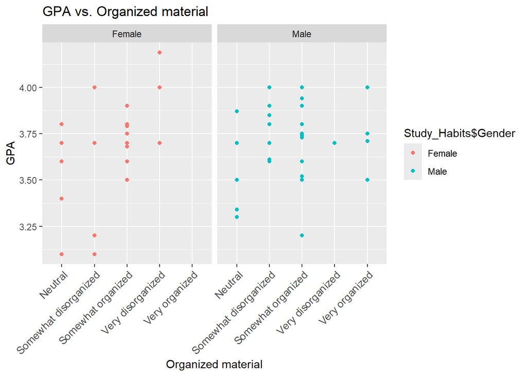

```r
library(ggplot2)
custom_data <- data.frame(
  Organized = Study_Habits$`Organized material`,
  GPA = GPA
)
ggplot(custom_data, aes(x = Organized, y = GPA, color = Study_Habits$Gender)) +
  geom_point() +
  geom_smooth(method = "lm", col = "blue") +
  facet_wrap(~ Study_Habits$Gender) +
  labs(title = "GPA vs. Organized material ",
       x = "Organized material",
       y = "GPA")+
  theme(axis.text.x = element_text(size = 10, angle = 45, hjust = 1))  # Adjust x-axis text properties
```

- –Hypothesis testing using Regression Analysis–

```r
model <- lm(GPA ~ Organized, data = custom_data)
summary(model)
```

```
##
## Call:
## lm(formula = GPA ~ Organized, data = custom_data)
##
## Residuals:
##     Min      1Q  Median      3Q     Max
## -0.5850 -0.1576  0.0150  0.1106  0.3304
##
## Coefficients:
##                                Estimate Std. Error t value Pr(>|t|)
## (Intercept)                     3.58944    0.04832  74.278   <2e-16 ***
## OrganizedSomewhat disorganized  0.09556    0.07044   1.356   0.1792
## OrganizedSomewhat organized     0.10449    0.06008   1.739   0.0862 .
## OrganizedVery disorganized      0.26816    0.10364   2.587   0.0117 *
## OrganizedVery organized         0.10256    0.10364   0.989   0.3257
## ---
## Signif. codes:  0 '***' 0.001 '**' 0.01 '*' 0.05 '.' 0.1 ' ' 1
##
## Residual standard error: 0.205 on 72 degrees of freedom
## Multiple R-squared:  0.09361,    Adjusted R-squared:  0.04326
## F-statistic: 1.859 on 4 and 72 DF,  p-value: 0.127
```

- high p-value (greater than 0.05) indicates that the effect of Organized material on GPA is not statistically significant. Thus, there’s no evidence that Organized material has a meaningful impact on GPA in our dataset.
- **#GPA vs Homework’s time**
- –Visualization–

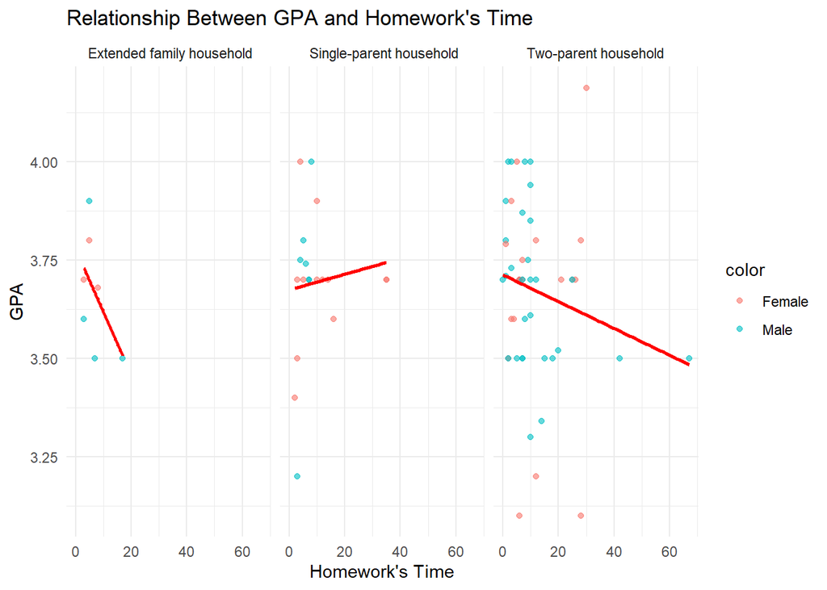

```r
custom_data <- na.omit(data.frame(
  Time = as.numeric(Study_Habits$`Homework's time`),
  GPA = as.numeric(GPA),
  Family_Structure = Study_Habits$`Family Structure`,
  color = Study_Habits$Gender
))

ggplot(custom_data, aes(y = GPA, x = Time, color = color)) +
  geom_point(alpha = 0.6) +
  geom_smooth(method = "lm", col = "red", se = FALSE) +
  facet_wrap(~ Family_Structure) +
  labs(title = "Relationship Between GPA and Homework's Time",
       x = "Homework's Time",
       y = "GPA") +
  theme_minimal()
```

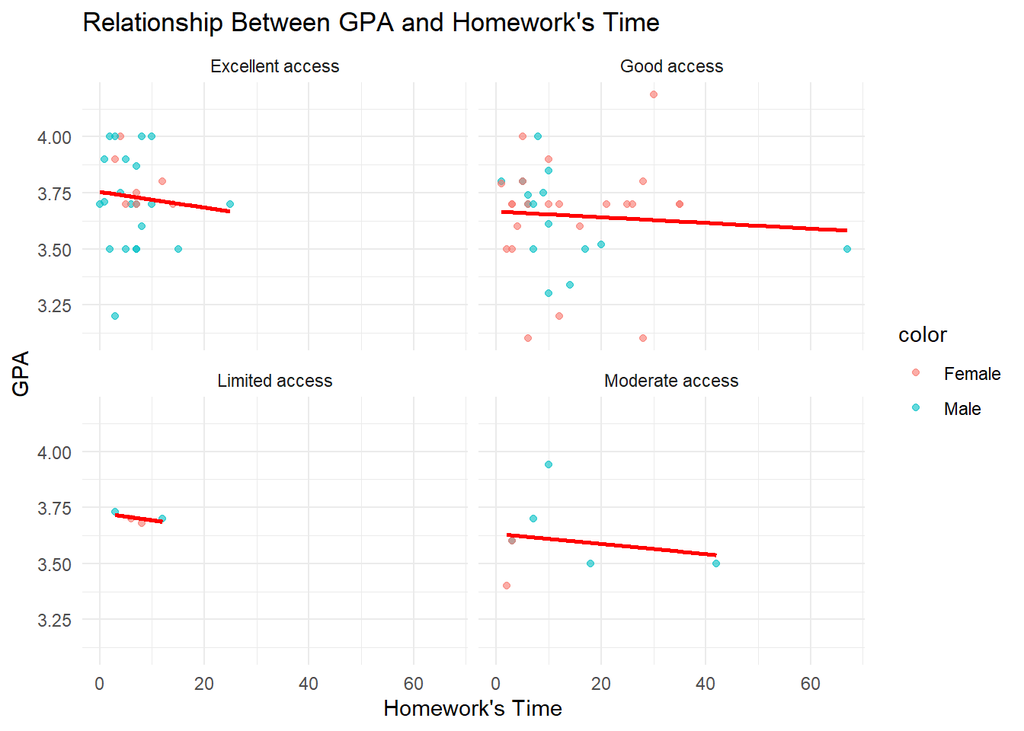

```r
custom_data <- na.omit(data.frame(
  Time = as.numeric(Study_Habits$`Homework's time`),
  GPA = as.numeric(GPA),
  Dig = Study_Habits$`Digital Access`,
  color = Study_Habits$Gender
))

ggplot(custom_data, aes(y = GPA, x = Time, color = color)) +
  geom_point(alpha = 0.6) +
  geom_smooth(method = "lm", col = "red", se = FALSE) +
  facet_wrap(~ Dig) +
  labs(title = "Relationship Between GPA and Homework's Time",
       x = "Homework's Time",
       y = "GPA") +
  theme_minimal()
```

- –Hypothesis testing using Regression Analysis–

```r
model <- lm(GPA ~ Time, data = custom_data)
summary(model)
```

```
##
## Call:
## lm(formula = GPA ~ Time, data = custom_data)
##
## Residuals:
##      Min       1Q   Median       3Q      Max
## -0.59034 -0.09810  0.01224  0.09674  0.55969
##
## Coefficients:
##              Estimate Std. Error t value Pr(>|t|)
## (Intercept)  3.705850   0.033310 111.253   <2e-16 ***
## Time        -0.002585   0.002173  -1.189    0.238
## ---
## Signif. codes:  0 '***' 0.001 '**' 0.01 '*' 0.05 '.' 0.1 ' ' 1
##
## Residual standard error: 0.209 on 75 degrees of freedom
## Multiple R-squared:  0.01852,    Adjusted R-squared:  0.005429
## F-statistic: 1.415 on 1 and 75 DF,  p-value: 0.238
```

- high p-value (greater than 0.05) indicates that the effect of Homework’s time on GPA is not statistically significant. Thus, there’s no evidence that Homework’s time has a meaningful impact on GPA in our dataset.
- **#GPA vs Planning for study Sessions**
- –Visualization–

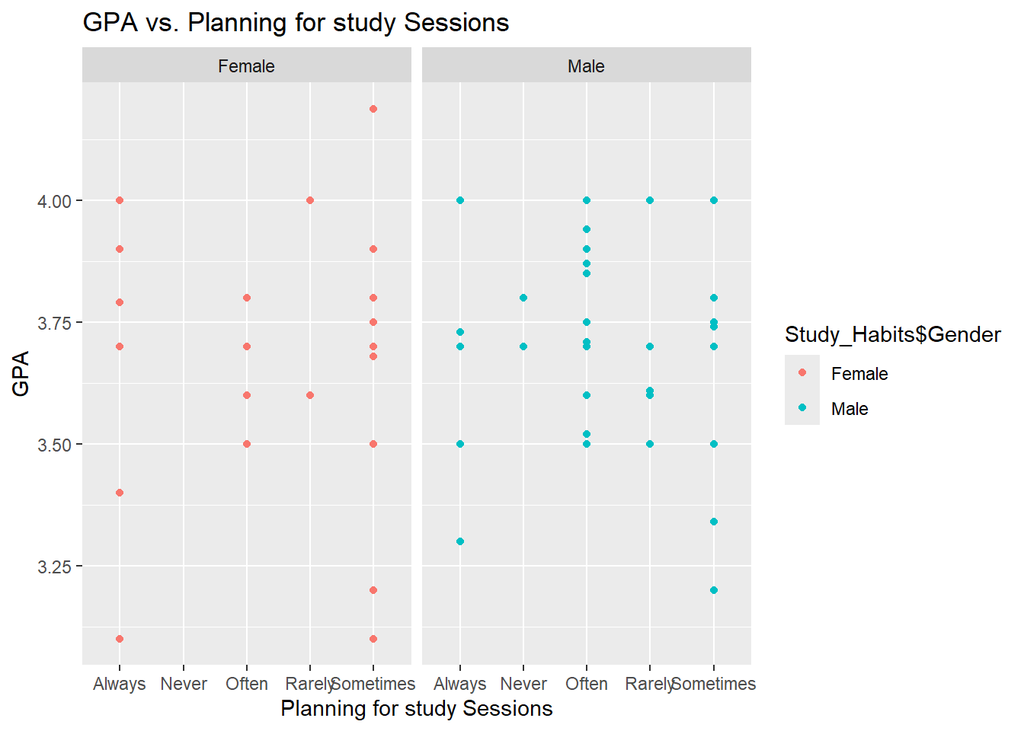

```r
library(ggplot2)
custom_data <- data.frame(
  Plan = Study_Habits$`Planning for study Sessions`,
  GPA = GPA
)
ggplot(custom_data, aes(x = Plan, y = GPA, color = Study_Habits$Gender)) +
  geom_point() +
  geom_smooth(method = "lm", col = "blue") +
  facet_wrap(~ Study_Habits$Gender) +
  labs(title = "GPA vs. Planning for study Sessions ",
       x = "Planning for study Sessions",
       y = "GPA")
```

- –Hypothesis testing using Regression Analysis–

```r
model <- lm(GPA ~ Plan, data = custom_data)
summary(model)
```

```
##
## Call:
## lm(formula = GPA ~ Plan, data = custom_data)
##
## Residuals:
##      Min       1Q   Median       3Q      Max
## -0.55861 -0.14556  0.04040  0.09139  0.52939
##
## Coefficients:
##               Estimate Std. Error t value Pr(>|t|)
## (Intercept)    3.64556    0.05027  72.522   <2e-16 ***
## PlanNever      0.10444    0.15896   0.657    0.513
## PlanOften      0.06404    0.06593   0.971    0.335
## PlanRarely     0.04444    0.08707   0.510    0.611
## PlanSometimes  0.01305    0.06712   0.194    0.846
## ---
## Signif. codes:  0 '***' 0.001 '**' 0.01 '*' 0.05 '.' 0.1 ' ' 1
##
## Residual standard error: 0.2133 on 72 degrees of freedom
## Multiple R-squared:  0.01923,    Adjusted R-squared:  -0.03525
## F-statistic: 0.353 on 4 and 72 DF,  p-value: 0.8411
```

- high p-value (greater than 0.05) indicates that the effect of Planning for study Sessions on GPA is not statistically significant. Thus, there’s no evidence that Planning for study Sessions has a meaningful impact on GPA in our dataset.
- **#GPA vs Exam Preparation**
- –Visualization–

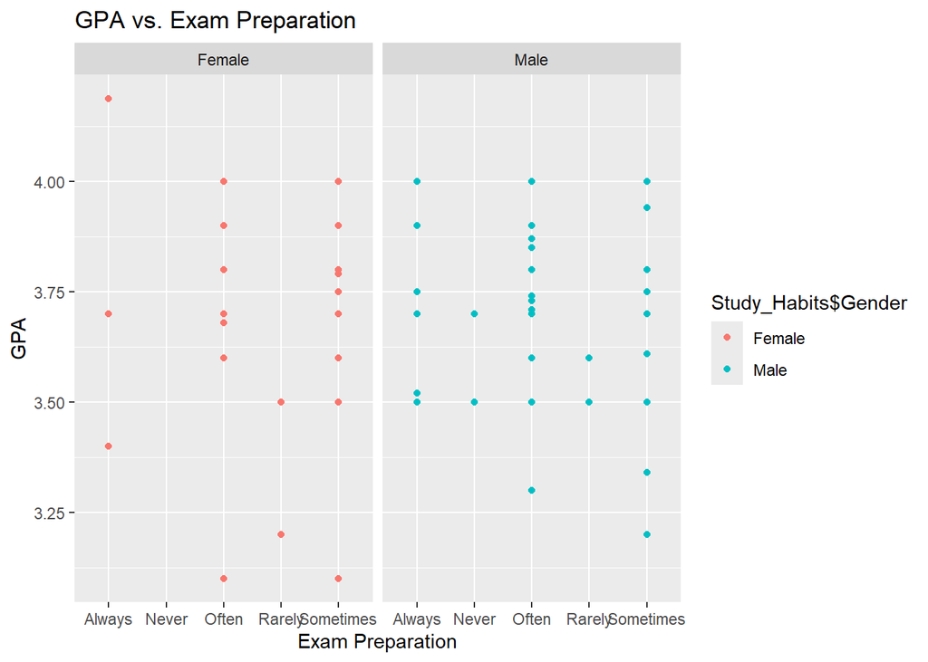

```r
library(ggplot2)
custom_data <- data.frame(
  Prep = Study_Habits$`Exam Preparation`,
  GPA = GPA
)
ggplot(custom_data, aes(x = Prep, y = GPA, color = Study_Habits$Gender)) +
  geom_point() +
  geom_smooth(method = "lm", col = "blue") +
  facet_wrap(~ Study_Habits$Gender) +
  labs(title = "GPA vs. Exam Preparation ",
       x = "Exam Preparation",
       y = "GPA")
```

- –Hypothesis testing using Regression Analysis–

```r
model <- lm(GPA ~ Prep, data = custom_data)
summary(model)
```

```
##
## Call:
## lm(formula = GPA ~ Prep, data = custom_data)
##
## Residuals:
##      Min       1Q   Median       3Q      Max
## -0.61933 -0.10000  0.01862  0.11929  0.50662
##
## Coefficients:
##               Estimate Std. Error t value Pr(>|t|)
## (Intercept)    3.68138    0.05723  64.321   <2e-16 ***
## PrepNever     -0.08138    0.15674  -0.519   0.6052
## PrepOften      0.03795    0.06852   0.554   0.5814
## PrepRarely    -0.23138    0.11799  -1.961   0.0537 .
## PrepSometimes -0.01067    0.06926  -0.154   0.8780
## ---
## Signif. codes:  0 '***' 0.001 '**' 0.01 '*' 0.05 '.' 0.1 ' ' 1
##
## Residual standard error: 0.2064 on 72 degrees of freedom
## Multiple R-squared:  0.08176,    Adjusted R-squared:  0.03074
## F-statistic: 1.603 on 4 and 72 DF,  p-value: 0.183
```

- high p-value (greater than 0.05) indicates that the effect of Exam Preparation on GPA is not statistically significant. Thus, there’s no evidence that Exam Preparation has a meaningful impact on GPA in our dataset.
- **#GPA vs Taking Notes**
- –Visualization–

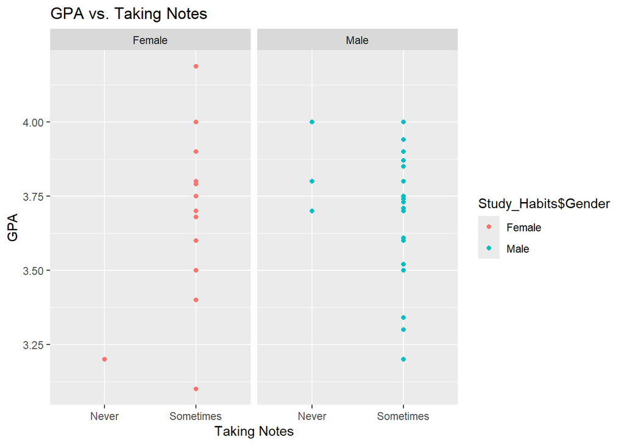

```r
library(ggplot2)
custom_data <- data.frame(
  Notes = Study_Habits$`Taking Notes`,
  GPA = GPA
)
ggplot(custom_data, aes(x = Notes, y = GPA, color = Study_Habits$Gender)) +
  geom_point() +
  geom_smooth(method = "lm", col = "blue") +
  facet_wrap(~ Study_Habits$Gender) +
  labs(title = "GPA vs. Taking Notes ",
       x = "Taking Notes",
       y = "GPA")
```

- –Hypothesis testing using Regression Analysis–

```r
model <- lm(GPA ~ Notes, data = custom_data)
summary(model)
```

```
##
## Call:
## lm(formula = GPA ~ Notes, data = custom_data)
##
## Residuals:
##      Min       1Q   Median       3Q      Max
## -0.57833 -0.15833  0.02167  0.12167  0.50967
##
## Coefficients:
##                Estimate Std. Error t value Pr(>|t|)
## (Intercept)    3.675000   0.105500  34.834   <2e-16 ***
## NotesSometimes 0.003329   0.108352   0.031    0.976
## ---
## Signif. codes:  0 '***' 0.001 '**' 0.01 '*' 0.05 '.' 0.1 ' ' 1
##
## Residual standard error: 0.211 on 75 degrees of freedom
## Multiple R-squared:  1.258e-05,  Adjusted R-squared:  -0.01332
## F-statistic: 0.0009438 on 1 and 75 DF,  p-value: 0.9756
```

- high p-value (greater than 0.05) indicates that the effect of Taking Notes on GPA is not statistically significant. Thus, there’s no evidence that Taking Notes has a meaningful impact on GPA in our dataset.
- **#GPA vs Seek academic help**
- –Visualization–

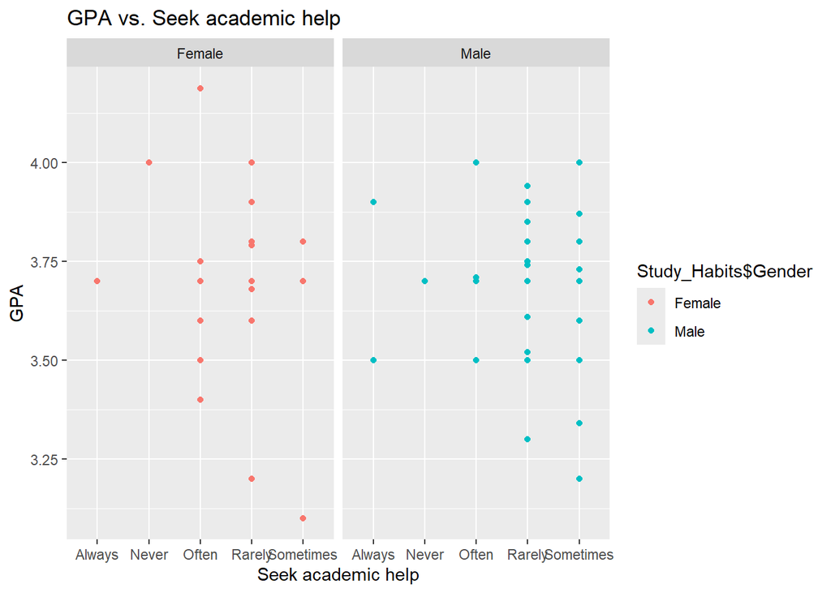

```r
library(ggplot2)
custom_data <- data.frame(
  Help = Study_Habits$`Seek academic help`,
  GPA = GPA
)
ggplot(custom_data, aes(x = Help, y = GPA, color = Study_Habits$Gender)) +
  geom_point() +
  geom_smooth(method = "lm", col = "blue") +
  facet_wrap(~ Study_Habits$Gender) +
  labs(title = "GPA vs. Seek academic help ",
       x = "Seek academic help",
       y = "GPA")
```

- –Hypothesis testing using Regression Analysis–

```r
model <- lm(GPA ~ Help, data = custom_data)
summary(model)
```

```
##
## Call:
## lm(formula = GPA ~ Help, data = custom_data)
##
## Residuals:
##      Min       1Q   Median       3Q      Max
## -0.54621 -0.14621  0.03247  0.09480  0.52047
##
## Coefficients:
##               Estimate Std. Error t value Pr(>|t|)
## (Intercept)    3.70000    0.10587  34.947   <2e-16 ***
## HelpNever      0.15000    0.18338   0.818    0.416
## HelpOften     -0.03247    0.11767  -0.276    0.783
## HelpRarely     0.00520    0.11403   0.046    0.964
## HelpSometimes -0.05379    0.11294  -0.476    0.635
## ---
## Signif. codes:  0 '***' 0.001 '**' 0.01 '*' 0.05 '.' 0.1 ' ' 1
##
## Residual standard error: 0.2117 on 72 degrees of freedom
## Multiple R-squared:  0.03318,    Adjusted R-squared:  -0.02054
## F-statistic: 0.6176 on 4 and 72 DF,  p-value: 0.6514
```

- high p-value (greater than 0.05) indicates that the effect of Seek academic help on GPA is not statistically significant. Thus, there’s no evidence that Seek academic help has a meaningful impact on GPA in our dataset.
- **#GPA vs Confidence in Academic success**
- –Visualization–

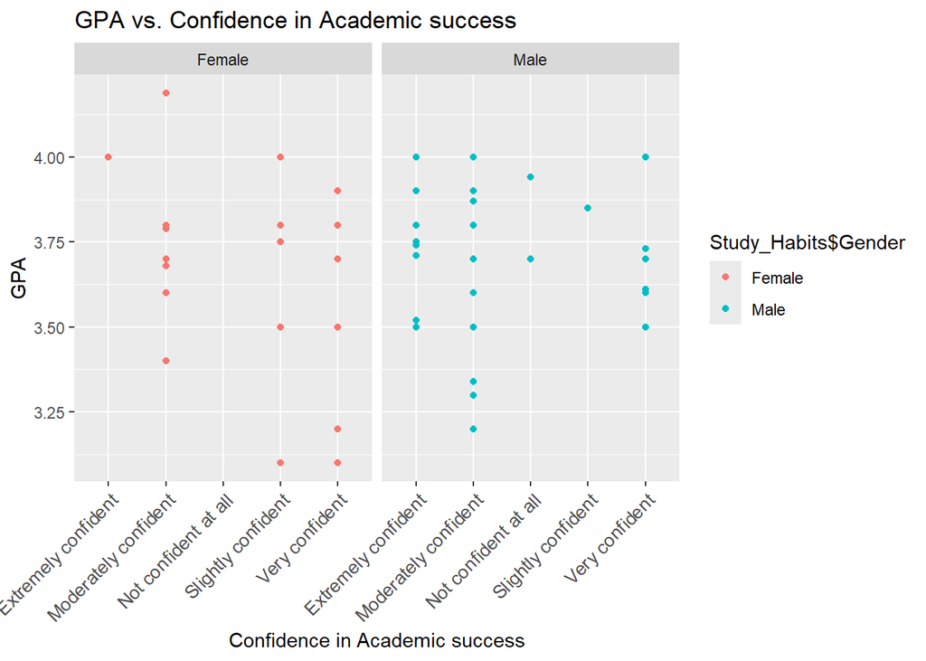

```r
library(ggplot2)
custom_data <- data.frame(
  Success = Study_Habits$`Confidence in Academic success`,
  GPA = GPA
)
ggplot(custom_data, aes(x = Success, y = GPA, color = Study_Habits$Gender)) +
  geom_point() +
  geom_smooth(method = "lm", col = "blue") +
  facet_wrap(~ Study_Habits$Gender) +
  labs(title = "GPA vs. Confidence in Academic success",
       x = "Confidence in Academic success",
       y = "GPA")+
  theme(axis.text.x = element_text(size = 10, angle = 45, hjust = 1))  # Adjust x-axis text properties
```

- –Hypothesis testing using Regression Analysis–

```r
model <- lm(GPA ~ Success, data = custom_data)
summary(model)
```

```
##
## Call:
## lm(formula = GPA ~ Success, data = custom_data)
##
## Residuals:
##      Min       1Q   Median       3Q      Max
## -0.56667 -0.15167  0.04506  0.11182  0.53306
##
## Coefficients:
##                             Estimate Std. Error t value Pr(>|t|)
## (Intercept)                  3.78818    0.06286  60.261   <2e-16 ***
## SuccessModerately confident -0.13324    0.07232  -1.842   0.0695 .
## SuccessNot confident at all  0.03182    0.16027   0.199   0.8432
## SuccessSlightly confident   -0.12152    0.10581  -1.148   0.2546
## SuccessVery confident       -0.13652    0.07591  -1.798   0.0763 .
## ---
## Signif. codes:  0 '***' 0.001 '**' 0.01 '*' 0.05 '.' 0.1 ' ' 1
##
## Residual standard error: 0.2085 on 72 degrees of freedom
## Multiple R-squared:  0.0627, Adjusted R-squared:  0.01063
## F-statistic: 1.204 on 4 and 72 DF,  p-value: 0.3166
```

- high p-value (greater than 0.05) indicates that the effect of Confidence in Academic success on GPA is not statistically significant. Thus, there’s no evidence that Confidence in Academic success has a meaningful impact on GPA in our dataset.
- **#GPA vs Study Habits Impact**
- –Visualization–

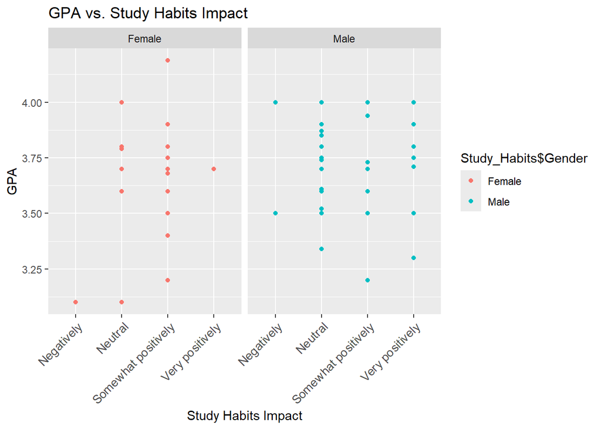

```r
library(ggplot2)
custom_data <- data.frame(
  Impact = Study_Habits$`Study Habits Impact`,
  GPA = GPA
)
ggplot(custom_data, aes(x = Impact, y = GPA, color = Study_Habits$Gender)) +
  geom_point() +
  geom_smooth(method = "lm", col = "blue") +
  facet_wrap(~ Study_Habits$Gender) +
  labs(title = "GPA vs. Study Habits Impact ",
       x = "Study Habits Impact",
       y = "GPA")+
  theme(axis.text.x = element_text(size = 10, angle = 45, hjust = 1))  # Adjust x-axis text properties
```

- –Hypothesis testing using Regression Analysis–

```r
model <- lm(GPA ~ Impact, data = custom_data)
summary(model)
```

```
##
## Call:
## lm(formula = GPA ~ Impact, data = custom_data)
##
## Residuals:
##      Min       1Q   Median       3Q      Max
## -0.60241 -0.10241  0.02606  0.09759  0.51406
##
## Coefficients:
##                           Estimate Std. Error t value Pr(>|t|)
## (Intercept)                 3.5250     0.1051  33.530   <2e-16 ***
## ImpactNeutral               0.1774     0.1121   1.582    0.118
## ImpactSomewhat positively   0.1489     0.1110   1.342    0.184
## ImpactVery positively       0.1594     0.1263   1.262    0.211
## ---
## Signif. codes:  0 '***' 0.001 '**' 0.01 '*' 0.05 '.' 0.1 ' ' 1
##
## Residual standard error: 0.2103 on 73 degrees of freedom
## Multiple R-squared:  0.0335, Adjusted R-squared:  -0.006216
## F-statistic: 0.8435 on 3 and 73 DF,  p-value: 0.4745
```

- high p-value (greater than 0.05) indicates that the effect of Study Habits Impact on GPA is not statistically significant. Thus, there’s no evidence that Study Habits Impact has a meaningful impact on GPA in our dataset.
- **#GPA vs Studying hours**
- –Visualization–

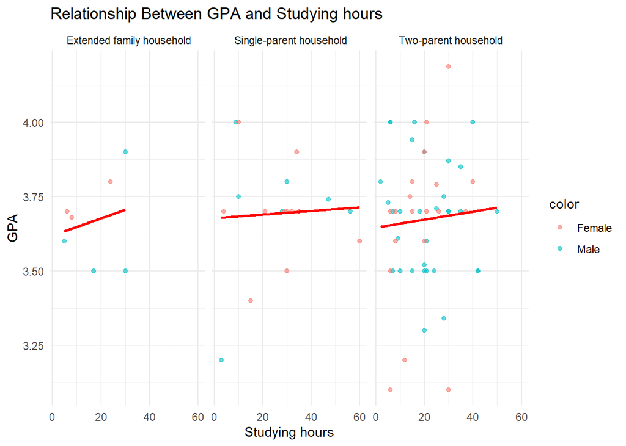

```r
library(ggplot2)
custom_data <- data.frame(
  Hours = Studying_hours,
  GPA = GPA,
  color = Study_Habits$Gender
)

ggplot(custom_data, aes(y = GPA, x = Hours, color = color)) +
  geom_point(alpha = 0.6) +
  geom_smooth(method = "lm", col = "red", se = FALSE) +
  facet_wrap(~ Study_Habits$`Family Structure`) +
  labs(title = "Relationship Between GPA and Studying hours",
       x = "Studying hours",
       y = "GPA") +
  theme_minimal()
```

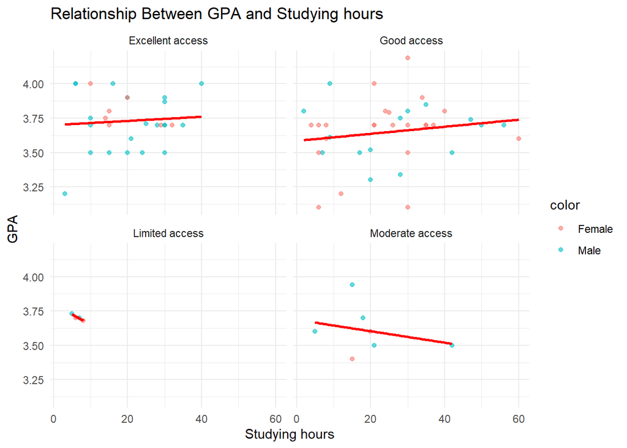

```r
library(ggplot2)
custom_data <- data.frame(
  Hours = Studying_hours,
  GPA = GPA,
  color = Study_Habits$Gender
)

ggplot(custom_data, aes(y = GPA, x = Hours, color = color)) +
  geom_point(alpha = 0.6) +
  geom_smooth(method = "lm", col = "red", se = FALSE) +
  facet_wrap(~ Study_Habits$`Digital Access`) +
  labs(title = "Relationship Between GPA and Studying hours",
       x = "Studying hours",
       y = "GPA") +
  theme_minimal()
```

- –Hypothesis testing using Regression Analysis–

```r
model <- lm(GPA ~ Hours, data = custom_data)
summary(model)
```

```
##
## Call:
## lm(formula = GPA ~ Hours, data = custom_data)
##
## Residuals:
##     Min      1Q  Median      3Q     Max
## -0.5883 -0.1558  0.0167  0.1080  0.4997
##
## Coefficients:
##             Estimate Std. Error t value Pr(>|t|)
## (Intercept) 3.650810   0.046813   77.99   <2e-16 ***
## Hours       0.001250   0.001837    0.68    0.499
## ---
## Signif. codes:  0 '***' 0.001 '**' 0.01 '*' 0.05 '.' 0.1 ' ' 1
##
## Residual standard error: 0.2104 on 75 degrees of freedom
## Multiple R-squared:  0.006129,   Adjusted R-squared:  -0.007123
## F-statistic: 0.4625 on 1 and 75 DF,  p-value: 0.4985
```

- high p-value (greater than 0.05) indicates that the effect of Studying hours on GPA is not statistically significant. Thus, there’s no evidence that Studying hours has a meaningful impact on GPA in our dataset.
- **#Digital Access vs Studying Methods**
- –Visualization–

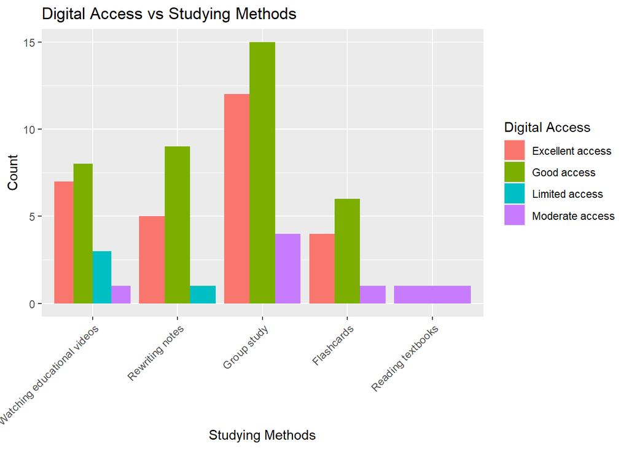

```r
library(ggplot2)
custom_data <- data.frame(
  V1 = Method,
  V2 = Study_Habits$`Digital Access`
)
ggplot(custom_data, aes(x = V1, fill = V2)) +
  geom_bar(position = "dodge") +
  labs(title = "Digital Access vs Studying Methods",
       x = "Studying Methods",
       y = "Count",
       fill = "Digital Access") +
  theme(axis.text.x = element_text(angle = 45, hjust = 1))
```

- –Hypothesis testing using chi-squared test–

```r
contingency_table <- table(Method, Study_Habits$`Digital Access`)
chi_squared_result <- chisq.test(contingency_table)
print(chi_squared_result)
```

```
##
##  Pearson's Chi-squared test
##
## data:  contingency_table
## X-squared = 19.214, df = 12, p-value = 0.08349
```

- high p-value (greater than 0.05) indicates that the effect of Digital Access on Studying Methods is not statistically significant. Thus, there’s no evidence that Digital Access has a meaningful impact on Studying Methods in our dataset.
- **#Study Environment vs Studying Methods**
- –Visualization–

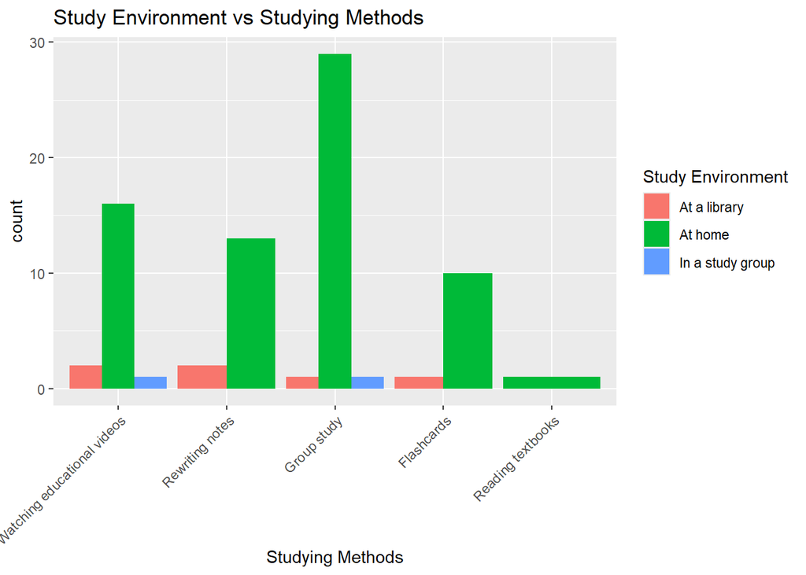

```r
library(ggplot2)
custom_data <- data.frame(
  V1 = Method,
  V2 = Study_Habits$`Study Environment`
)
ggplot(custom_data, aes(x = V1, fill = V2)) +
  geom_bar(position = "dodge") +
  labs(title = "Study Environment vs Studying Methods ",
       x = "Studying Methods",
       fill = "Study Environment",
       y = "count")+
  theme(axis.text.x = element_text(angle = 45, hjust = 1))
```

- –Hypothesis testing using chi-squared test–

```r
contingency_table <- table(Method, Study_Habits$`Study Environment`)
chi_squared_result <- chisq.test(contingency_table)
print(chi_squared_result)
```

```
##
##  Pearson's Chi-squared test
##
## data:  contingency_table
## X-squared = 3.117, df = 8, p-value = 0.9268
```

- high p-value (greater than 0.05) indicates that the effect of Study Environment on Studying Methods is not statistically significant. Thus, there’s no evidence that Study Environment has a meaningful impact on Studying Methods in our dataset.
- **#Taking Notes vs Studying Methods**
- –Visualization–

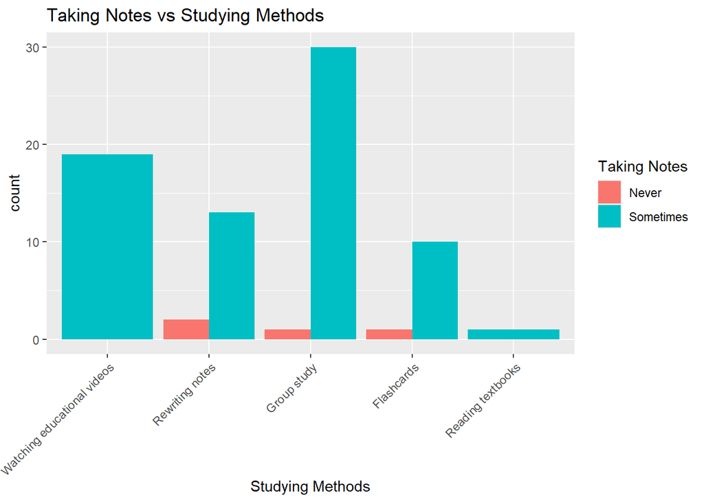

```r
library(ggplot2)
custom_data <- data.frame(
  V1 = Method,
  V2 = Study_Habits$`Taking Notes`
)
ggplot(custom_data, aes(x = V1, fill = V2)) +
  geom_bar(position = "dodge") +
  labs(title = "Taking Notes vs Studying Methods ",
       x = "Studying Methods",
       fill = "Taking Notes",
       y = "count")+
    theme(axis.text.x = element_text(angle = 45, hjust = 1))
```

- –Hypothesis testing using chi-squared test–

```r
contingency_table <- table(Method, Study_Habits$`Taking Notes`)
chi_squared_result <- chisq.test(contingency_table)
print(chi_squared_result)
```

```
##
##  Pearson's Chi-squared test
##
## data:  contingency_table
## X-squared = 3.6963, df = 4, p-value = 0.4487
```

- high p-value (greater than 0.05) indicates that the effect of Taking Notes on Studying Methods is not statistically significant. Thus, there’s no evidence that Taking Notes has a meaningful impact on Studying Methods in our dataset.
- **#Organized Material vs Studying Methods**
- –Visualization–

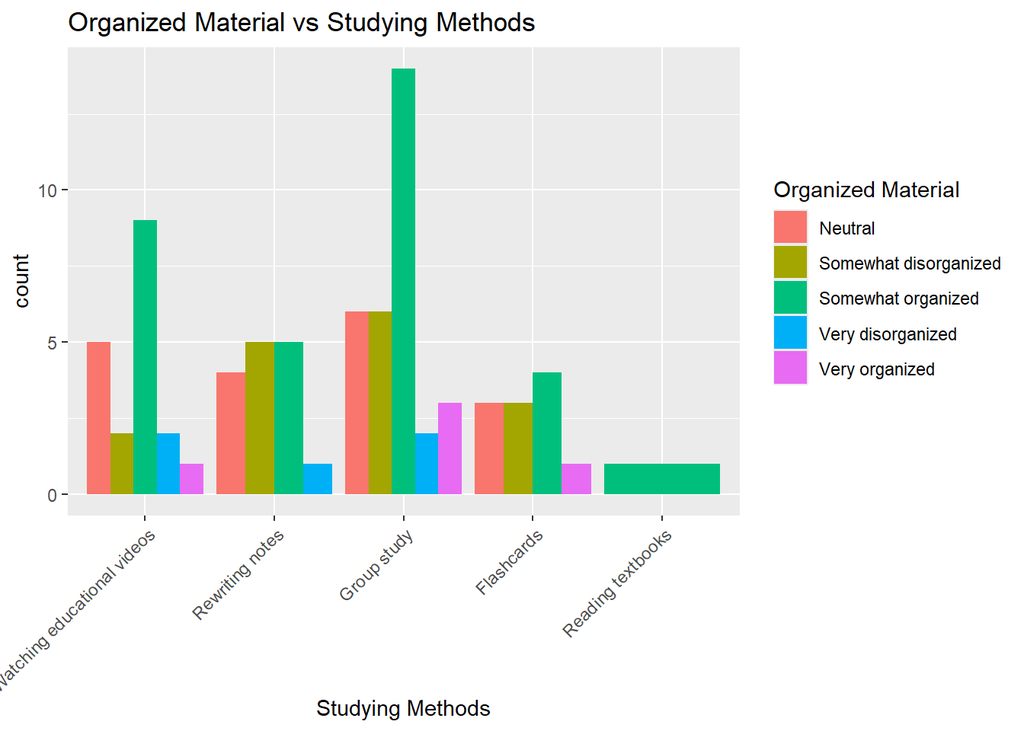

```r
library(ggplot2)
custom_data <- data.frame(
  V1 = Method,
  V2 = Study_Habits$`Organized material`
)
ggplot(custom_data, aes(x = V1, fill = V2)) +
  geom_bar(position = "dodge") +
  labs(title = "Organized Material vs Studying Methods ",
       x = "Studying Methods",
       fill = "Organized Material",
       y = "count")+
    theme(axis.text.x = element_text(angle = 45, hjust = 1))
```

- –Hypothesis testing using chi-squared test–

```r
contingency_table <- table(Method, Study_Habits$`Organized material`)
chi_squared_result <- chisq.test(contingency_table)
print(chi_squared_result)
```

```
##
##  Pearson's Chi-squared test
##
## data:  contingency_table
## X-squared = 7.4731, df = 16, p-value = 0.963
```

- high p-value (greater than 0.05) indicates that the effect of Organized Material on Studying Methods is not statistically significant. Thus, there’s no evidence that Organized Material has a meaningful impact on Studying Methods in our dataset.
- **#Homework’s time vs Studying Methods**
- –Visualization–

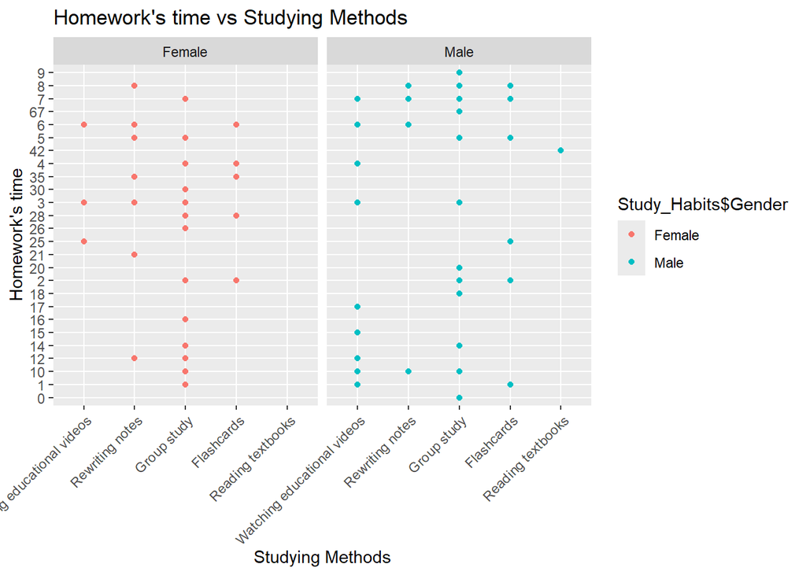

```r
library(ggplot2)
custom_data <- data.frame(
  V1 = Method,
  V2 = Study_Habits$`Homework's time`
)
ggplot(custom_data, aes(x = V1, y = V2, color = Study_Habits$Gender)) +
  geom_point() +
  geom_smooth(method = "lm", col = "blue") +
  facet_wrap(~ Study_Habits$Gender) +
  labs(title = "Homework's time vs Studying Methods ",
       x = "Studying Methods",
       y = "Homework's time")+
    theme(axis.text.x = element_text(angle = 45, hjust = 1))
```

- –Hypothesis testing using chi-squared test–

```r
contingency_table <- table(Method, Study_Habits$`Homework's time`)
chi_squared_result <- chisq.test(contingency_table)
print(chi_squared_result)
```

```
##
##  Pearson's Chi-squared test
##
## data:  contingency_table
## X-squared = 146.48, df = 100, p-value = 0.001706
```

- Appropriate p-value (lower than 0.05) indicates that the effect of Studying Method on Homework’s time is statistically significant. Thus, there’s enough evidence that Studying Method has a meaningful impact on Homework’s time in our dataset.
- **#Exam Preparation vs Studying Methods**
- –Visualization–

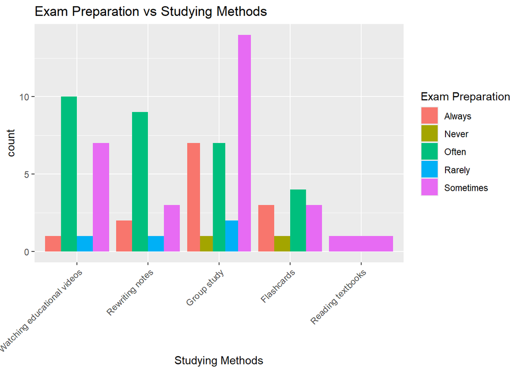

```r
library(ggplot2)
custom_data <- data.frame(
  V1 = Method,
  V2 = Study_Habits$`Exam Preparation`
)
ggplot(custom_data, aes(x = V1, fill = V2)) +
  geom_bar(position = "dodge") +
  labs(title = "Exam Preparation vs Studying Methods ",
       x = "Studying Methods",
       fill = "Exam Preparation",
       y = "count")+
    theme(axis.text.x = element_text(angle = 45, hjust = 1))
```

- –Hypothesis testing using chi-squared test–

```r
contingency_table <- table(Method, Study_Habits$`Exam Preparation`)
chi_squared_result <- chisq.test(contingency_table)
print(chi_squared_result)
```

```
##
##  Pearson's Chi-squared test
##
## data:  contingency_table
## X-squared = 14.91, df = 16, p-value = 0.5312
```

- high p-value (greater than 0.05) indicates that the effect of Exam Preparation on Studying Methods is not statistically significant. Thus, there’s no evidence that Exam Preparation has a meaningful impact on Studying Methods in our dataset.
- **#Confidence in Academic success vs Studying Methods**
- –Visualization–

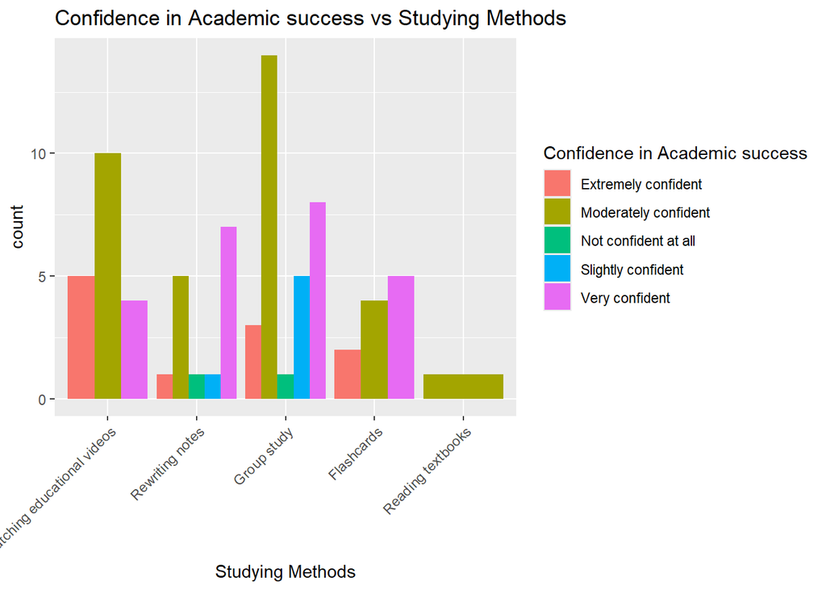

```r
library(ggplot2)
custom_data <- data.frame(
  V1 = Method,
  V2 = Study_Habits$`Confidence in Academic success`
)
ggplot(custom_data, aes(x = V1, fill = V2)) +
  geom_bar(position = "dodge") +
  labs(title = "Confidence in Academic success vs Studying Methods ",
       x = "Studying Methods",
       fill = "Confidence in Academic success",
       y = "count")+
    theme(axis.text.x = element_text(angle = 45, hjust = 1))
```

- –Hypothesis testing using chi-squared test–

```r
contingency_table <- table(Method, Study_Habits$`Confidence in Academic success`)
chi_squared_result <- chisq.test(contingency_table)
print(chi_squared_result)
```

```
##
##  Pearson's Chi-squared test
##
## data:  contingency_table
## X-squared = 14.938, df = 16, p-value = 0.5292
```

- high p-value (greater than 0.05) indicates that the effect of Confidence in Academic success on Studying Methods is not statistically significant. Thus, there’s no evidence that Confidence in Academic success has a meaningful impact on Studying Methods in our dataset.
- **#Study Habits Impact vs Studying Methods**
- –Visualization–

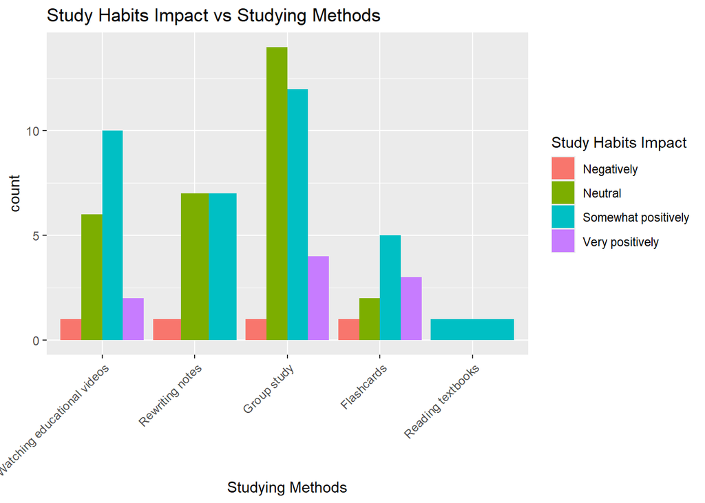

```r
library(ggplot2)
custom_data <- data.frame(
  V1 = Method,
  V2 = Study_Habits$`Study Habits Impact`
)
ggplot(custom_data, aes(x = V1, fill = V2)) +
  geom_bar(position = "dodge") +
  labs(title = "Study Habits Impact vs Studying Methods ",
       x = "Studying Methods",
       fill = "Study Habits Impact",
       y = "count")+
    theme(axis.text.x = element_text(angle = 45, hjust = 1))
```

- –Hypothesis testing using chi-squared test–

```r
contingency_table <- table(Method, Study_Habits$`Study Habits Impact`)
chi_squared_result <- chisq.test(contingency_table)
print(chi_squared_result)
```

```
##
##  Pearson's Chi-squared test
##
## data:  contingency_table
## X-squared = 8.5268, df = 12, p-value = 0.7427
```

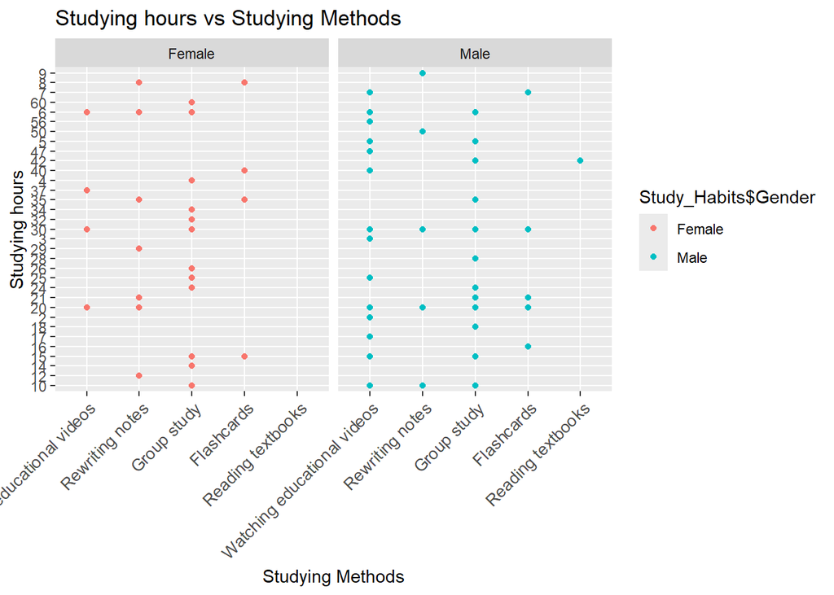

```r
library(ggplot2)
custom_data <- data.frame(
  V1 = Method,
  V2 = Study_Habits$`Studying hours`
)
ggplot(custom_data, aes(x = V1, y = V2, color = Study_Habits$Gender)) +
  geom_point() +
  geom_smooth(method = "lm", col = "blue") +
  facet_wrap(~ Study_Habits$Gender) +
  labs(title = "Studying hours vs Studying Methods ",
       x = "Studying Methods",
       y = "Studying hours")+
    theme(axis.text.x = element_text(size = 10, angle = 45, hjust = 1))  # Adjust x-axis text properties
```

- –Hypothesis testing using chi-squared test–

```r
contingency_table <- table(Method, Study_Habits$`Studying hours`)
chi_squared_result <- chisq.test(contingency_table)
print(chi_squared_result)
```

```
##
##  Pearson's Chi-squared test
##
## data:  contingency_table
## X-squared = 133.72, df = 128, p-value = 0.3469
```